# R Notebook

## Frequency of existing variant in gnomAD(gnomAD_AF)과 IMPACT의 관계

### 1. Dataset

분석하고자 하는 자료는 neurodevelopmental patients의 SCN2A mutation list이다. 해당하는 자료를 불러오고 추가로 주어진 header를 확인한다.

```r
d = read.csv('table.scn2a.vep_20190916.filtered.txt', sep='\t')
header = read.csv('table.scn2a.vep_20190916.headers.txt',sep='\t')
```

다음은 수업시간에 다룬 SCN2A patient의 data이다.

```r
options(stringsAsFactors = F)
d1 = read.csv('https://www.dropbox.com/s/he7r6v4hxu0ibno/tableS1.Sanders2018.txt?dl=1', sep='\t')
```

Plot으로 표현하고자 하는 주제는 frequency of existing variant in gnomAD(gnomAD_AF)과 IMPACT의 관계이다. 따라서 필요한 column은 다음과 같다.

1. Consequence: Consequence type
2. IMPACT: Subjective impact classification of consequence type
3. gnomAD_AF: Frequency of existing variant in gnomAD exomes combined population

IMPACT와의 관계를 살피기 위해 IMPACT에 따라 high, moderate, low로 구분지을 수 있다.

```r
d2 <- d  %>%
  select( Consequence, gnomAD_AF, IMPACT) %>%
  mutate(gnomAD = log(gnomAD_AF)*100 + 1500)

high_impact <- d2 %>%
  filter(IMPACT == "HIGH") %>%
  arrange(Consequence)

moderate_impact <-  d2 %>%
  filter(IMPACT == "MODERATE") %>%
  arrange(Consequence)

low_impact <-  d2 %>%
  filter(IMPACT == "LOW") %>%
  arrange(Consequence)
```

A single-nucleotide variant (SNV) is a variation in a single nucleotide without any limitations of frequency and may arise in somatic cells. A somatic single-nucleotide variation (e.g., caused by cancer) may also be called a single-nucleotide alteration

IMPACT는 consequence에 따라 주는 영향에 의해서 분류되었으므로 해당 consequence를 확인했다.

**low_impact**

synonymous_variant

**moderate_impact**

inframe_deletion, inframe_insertion, missense_variant, splice_region_variant

**high_impact**

frameshift_variant, stop_gained, stop_lost

```r
low_impact %>% count(Consequence)
```

| Consequence | n |
| --- | --- |
| synonymous_variant | 430 |

```r
moderate_impact %>% count(Consequence)
```

| Consequence | n |
| --- | --- |
| inframe_deletion | 2 |
| inframe_insertion | 4 |
| missense_variant | 758 |
| missense_variant,splice_region_variant | 13 |

```r
high_impact %>% count(Consequence)
```

| Consequence | n |
| --- | --- |
| frameshift_variant | 12 |
| stop_gained | 28 |
| stop_lost | 1 |

그리고 SCN2A mutation patients data에서의 consequence 비율을 확인해 impact와의 관계를 살펴보았다.

```r
d1 %>% count(Effect)
```

| Effect | n |
| --- | --- |
| Frameshift | 21 |
| Missense | 223 |
| Nonsense | 19 |

위에서 impact로 분류한 기준을 고려했을 때 high_impact에 해당되는 frameshift와 nonsense(= stop_)는 합해도 40명의 환자만 해당이 된다. 의외로 moderate_impact에 속하는 missense가 상당수를 차지했다.

SCN2A mutation list인 d에서도 column중 `group`에서 disease 이름이 나온 data의 impact를 살펴볼 수 있을 것이다.

```r
d3 <- d  %>%
  filter(!Group == "gnomAD") %>%
  select( Consequence, gnomAD_AF, IMPACT, Group) %>%
  mutate(gnomAD = log(gnomAD_AF)*100 + 1500)

d3 %>% count(IMPACT, Consequence, Group)
```

| IMPACT | Consequence | Group | n |
| --- | --- | --- | --- |
| HIGH | frameshift_variant | ASD/DD | 8 |
| HIGH | frameshift_variant | Unclear | 1 |
| HIGH | stop_gained | ASD/DD | 16 |
| HIGH | stop_gained | Schizophrenia | 1 |
| HIGH | stop_gained | Unclear | 2 |
| MODERATE | missense_variant | ASD/DD | 40 |
| MODERATE | missense_variant | BIS | 33 |
| MODERATE | missense_variant | IEE | 108 |
| MODERATE | missense_variant | IEE_Mild/Ataxia | 5 |
| MODERATE | missense_variant | Other | 1 |

[output cut: 3 more lines]

```r
NA
```

환자의 데이터와 마찬가지로 대부분 moderate IMPACT의 missense mutation이었고 일부는 high IMPACT의 frameshift와 stop_gain이었다.

### 2. Visualization

IMPACT를 기준으로 나눠 variant의 gnomAD 값을 비교해 jitter plot으로 나타냈다. 이때 각 IMPACT에 해당하는 consequence를 확인하기 위해 다른 색상으로 표현했다. 또한 gnomAD값이 0인 경우를 제외하고 axis를 한정해 해당하는 값만 확인했다.

Mutation의 결과가 disease로 나타낸 경우를 똑같이 jitter plot으로 나타내 전체 data 대비 어떤 위치에 존재하는지 확인했다. 그리고 bar plot으로 나타내 각 IMPACT에 해당되는 disease의 비율을 통해 IMPACT와 disease간의 관계를 알아보고자 했다.

```r
p1 <- d2 %>% filter(gnomAD != 0) %>%
  ggplot(aes(x= gnomAD, y= IMPACT, col=Consequence)) +
  geom_jitter(alpha=.7, size=0.6) +
  scale_x_continuous(limits = c(100, 1000))+
  labs(x='Frequency of existing variant(Log)',
       title='Impact and Frequency of Existing Variant')

p2 <- d3 %>% filter(gnomAD != 0) %>%
  ggplot(aes(x= gnomAD, y= IMPACT, col=Group)) +
  geom_jitter(alpha=.7, size=0.6) +
  scale_x_continuous(limits = c(100, 1000))+
  labs(x='Frequency of existing variant(Log)')

p3 <- d3 %>% filter(gnomAD != 0) %>%
  ggplot(aes(x= IMPACT, fill=Group)) +
  geom_bar(width=0.5) +
  coord_flip()
  scale_x_continuous(limits = c(100, 1000))
```

```
<ScaleContinuousPosition>
 Range:
 Limits:  100 -- 1e+03
```

```r
plots <- align_plots(p1, p2, align = 'v', axis = 'l')
```

```
Removed 3 rows containing missing values (geom_point).
```

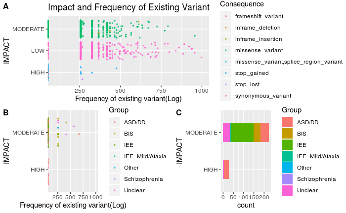

```r
bottom_row <- plot_grid(plots[[2]], p3, labels = c('B', 'C'), label_size = 12)
plot_grid(plots[[1]], bottom_row, labels = c('A', ''), label_size = 12, ncol = 1)
```

```r
NA
NA
```

Plot에서 보듯이 moderate impact의 대부분은 missense variant임을 확인할 수 있었다. Low impact는 synonymous variant로만 이루어져있으며 high impact의 경우 stop gained/lost의 dot이 확인되었다.

SCN2A mutation list중에서 disease로 분류된 데이터를 살펴보면 대부분 Moderate IMPACT에 속하고 High IMPACT에 일부분 속하며 Low IMPACT는 해당되지 않았다.

결론적으로, mutation은 대부분 low impact와 moderate impact를 가지며 이때 frequency는 다양하게 분포되어있지만 낮은 쪽에 더 분포되어있다. 그리고 High의 경우 variant 자체가 적게 나타났고 frequency 또한 높은 편은 아니였다.

반면에 실제로 질병으로까지 발병되기 위해서는 IMPACT가 moderate나 high한 수준에 속해야 하며 moderate IMPACT의 경우가 더 많이 관찰되었다. 이때 gnomAD의 값은 뚜렷한 연관성을 보이지 않았다.

데이터를 종합해 보았을 때 high IMPACT의 mutation일 경우 생명에 지장을 주는 수준이라서 moderate IMPACT mutation이 일어나 생존은 하지만 질병으로 나타나는 비율이 높은 것인 가라는 하나의 가설을 생각해 볼 수 있었다.